# Mini Report: Bonanza Hares

Ruby Harris-Gavin

11/20/2020

### 1. Introduction

This report provides an exploratory overview of weight differences in male and female juvenile hares across three sites of the Bonanza Creek Long-term Ecological Research (LTER), as well as the relationship between weight and hindfoot length in juvenile hares. Data was collected from 1999-2012 at sites Bonanza Black Spruce, Bonanza Mature, and Bonanza Riparian (Kielland et al. 2017).

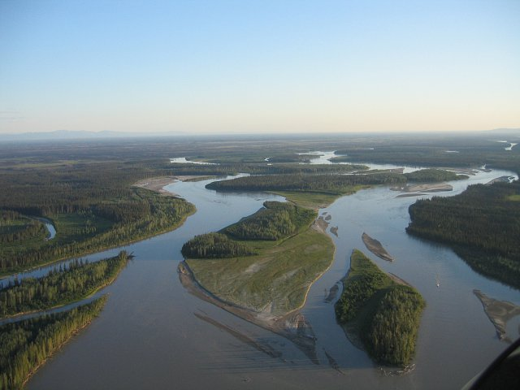

**Figure 1.** Bonanza Creek Experimental Forest. Credit: Roger Ruess

### 2. Data & Analyses

Data on Snowshoe hare measurements were collected and made available by Dr. Knut Kielland and colleagues at the Bonanza Creek Long-term Ecological Research (LTER), which is 20km southwest of Fairbanks, Alaska. The data contain observations of individual Snowshoe hares that were trapped between 1999 and 2012, but the research continues today.

### 3. Exploratory Findings

#### I. Annual Juvenile Hare Trap Counts

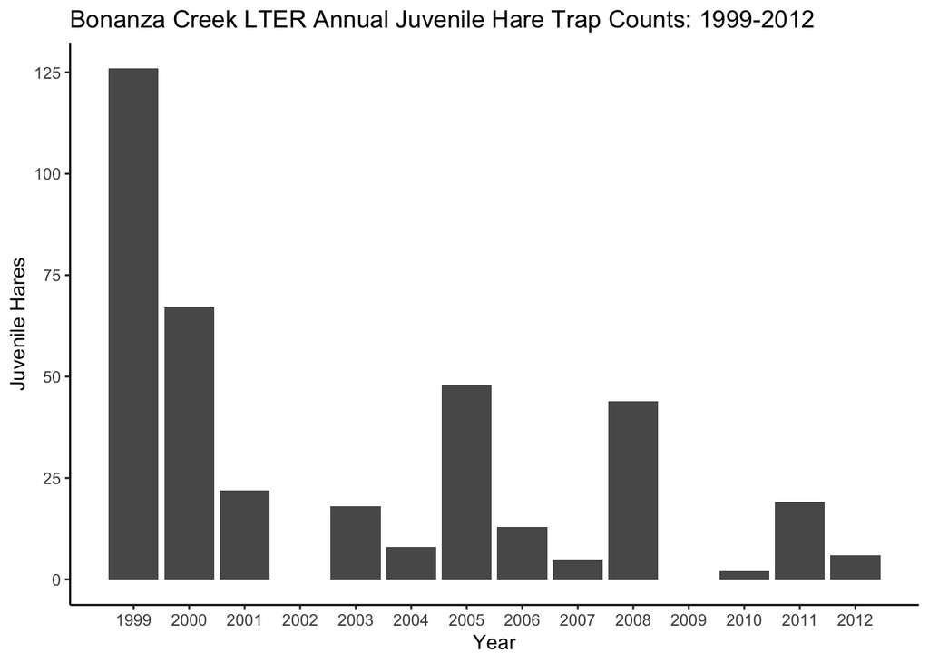

**Figure 2.** Total number of juvenile hares trapped each year at Bonanza Creek LTER sites from 1999-2012. Data: Kielland et al. 2017.

Since trapping began in 1999, the number of juveniles trapped appears to have steadily decreased. The maximum count is in the first trapping year (1999) with a total of 126 juvenile hares trapped. However, there is great fluctuation in the number of juveniles caught throughout the 14 year span of this dataset, with some years (2002, 2009) resulting in 0 juveniles trapped. Perhaps in 1999 when the study began, there was a significant effort to trap hares which resulted in this large total count. Because of this, it is possible that 1999 had an unusually high count, and in fact the number of juveniles caught has remained steady after that unusual peak.

#### II. Visualization of Juvenile Hare Weights

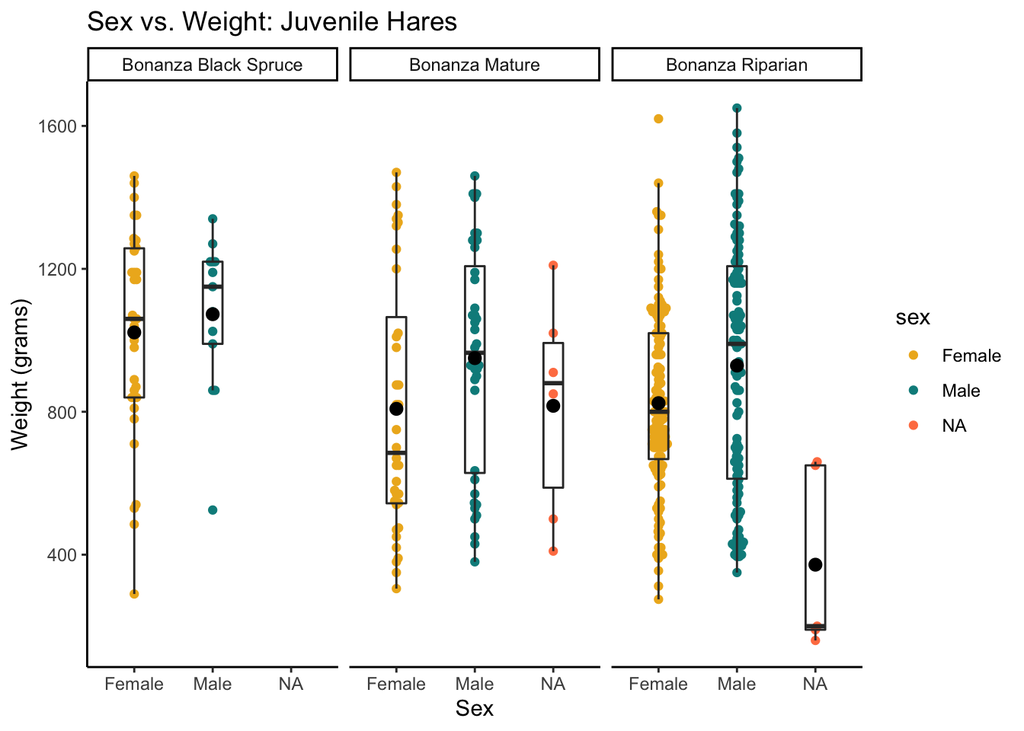

**Figure 3.** Comparison of male and female juvenile hare weight at sites Bonanza Black Spruce, Bonanza Mature, and Bonanza Riparian. Box endpoints indicate the 25<sup>th</sup> and 75<sup>th</sup> percentile values; the black line and black point within the box indicate the median and mean value for each sex, respectively. Data: Kielland et al. 2017.

On average, it appears male juvenile hares weigh more than female juvenile hares at all three sites. It is interesting to note that both the males and the females at the Bonanza Black Spruce site on average weigh more than the hares at either Bonanza Mature or Bonanza Riparian. However, the hares at Bonanza Riparian have the largest distribution of weights, including the highest values at over 1600g. One explanation for this could be the differences in resource availability at each site, or the number of predators that live near these sites.

#### III. Juvenile Male and Female Snowshoe Hare Weight: Descriptive Statistics

**Table 1.** Summary statistics for juvenile male and female Snowshoe hare weight. Data: Kielland et al. 2017.

| Sex | Mean weight (g) | Standard deviation (g) | Sample size |
| --- | --- | --- | --- |
| Female | 855.39 | 292.25 | 200 |
| Male | 945.86 | 333.22 | 163 |
| NA | 614.55 | 357.59 | 15 |

Hare weight (grams) was compared across the two sexes; site was not included as a variable here, but should be investigated moving forward. On average, juvenile male Snowshoe hares (945.86 $\pm$ 333.22g, *n* = 163) weighed more than juvenile females (855.39 $\pm$ 292.25g, *n* = 200).

#### IV. Relationship between juvenile weight & hindfoot length

An exploratory visualization of the relationship between juvenile weight and hindfoot length was completed.

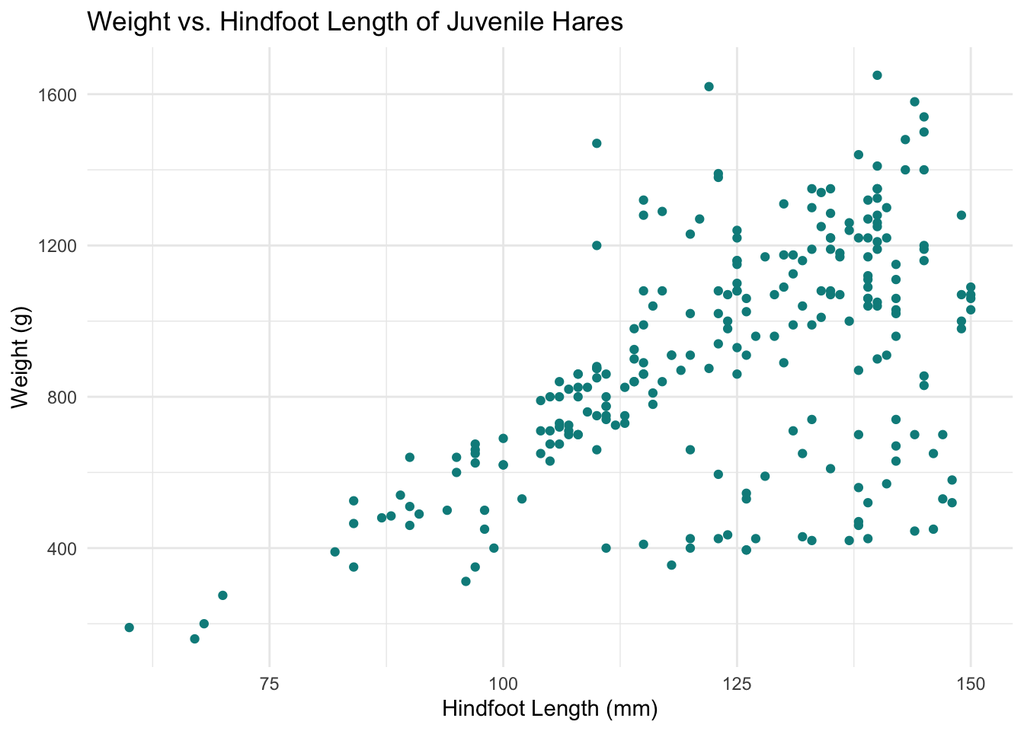

**Figure 4.** Relationship between juvenile weight (g) and hindfoot length (mm). Points indicate individual hare measurements. Data: Kielland et al. 2017.

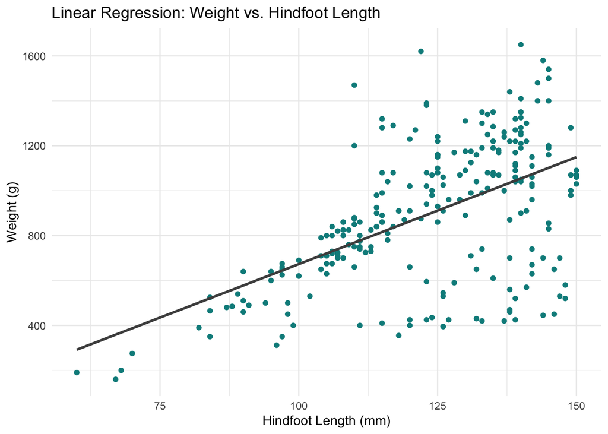

**Figure 5.** Linear regression exploring relationship between juvenile weight (g) and hindfoot length (mm). Linear model summary: $\beta$<sub>1</sub> = 9.52 g mm<sup>-1</sup>, p < 0.05, R<sup>2</sup> = 0.3, Pearson’s *r* = 0.55). Data: Kielland et al. 2017.

### Summary

Exploratory analysis of the Kielland et al. 2017 data reveals the following initial findings:

- The number of juveniles caught has been decreasing since a large peak in 1999.
- On average, male juvenile hares weigh more than female juvenile hares ((945.86 $\pm$ 333.22g, *n* = 163) and (855.39 $\pm$ 292.25g, *n* = 200), respectively).
- Using simple linear regression, there is a positive and significant correlation between juvenile weight and hindfoot length ( $\beta$<sub>1</sub> = 9.52 g mm<sup>-1</sup>, p < 0.05, R<sup>2</sup> = 0.3, Pearson’s *r* = 0.55). However, because there isn’t a strong relationship, further analysis of this relationship is recommended.

Next steps:

- Understanding the factors that influence weight of juvenile hares at each research site (Bonanza Black Spruce, Bonanza Mature, and Bonanza Riparian).
- Further analyses looking at the relationship between weight and hindfoot length (such as incorporating sex or site)

### Citations

Kielland, K., F.S. Chapin, R.W. Ruess, and Bonanza Creek LTER. 2017. Snowshoe hare physical data in Bonanza Creek Experimental Forest: 1999-Present ver 22. Environmental Data Initiative. https://doi.org/10.6073/pasta/03dce4856d79b91557d8e6ce2cbcdc14 (Accessed 2020-11-21).

Ruess, Roger. “Credit: Roger Ruess.” Bonanza Creek LTER: Bonanza Creek Experimental Forest. Photograph. (http://www.lter.uaf.edu/research/study-sites-bcef)